# Informe Final Vergara

Matias A. Vergara

2026-06-24

# Sistema de estudio

Para este trabajo, se generó un conjunto de datos simulados que recrea un diseño de muestreo en el Parque Nacional Nahuelbuta, un sistema de bosque lluvioso de alta montaña dominado por Nothofagus pumilio. El objetivo de este estudio es evaluar si el muérdago *Desmaria mutabilis* desencadena una cascada de facilitación multitrófica sobre las comunidades de artrópodos epígeos y aves insectívoras en este sistema. La hipótesis propone que la presencia de *D. mutabilis* incrementa la diversidad en las comunidades de artrópodos epígeos, y que este aumento en la diversidad actúa como mediador del incremento en la diversidad de aves insectívoras. El diseño contempla 30 parcelas divididas equitativamente: 15 árboles con presencia de *D. mutabilis* y 15 árboles sin muérdago. La pregunta que guía este análisis es: ¿La presencia de *Desmaria mutabilis* desencadena una cascada de facilitación multitrófica sobre la composición y diversidad de las comunidades de artrópodos epígeos y aves insectívoras en un bosque de alta montaña de Nothofagus pumilio del Parque Nacional Nahuelbuta?

```r
library(vegan)

set.seed(42)
n_plots <- 30
desmaria <- c(rep(1, 15), rep(0, 15)) # Presencia binaria

# Funcion auxiliar para hacer el cálculo de diversidad para que la diversidad de aves se haga en función de la de artrópodos.

shannon_H <- function(counts) {
  counts <- counts[counts > 0]
  if (length(counts) == 0) return(0)
  p <- counts / sum(counts)
  -sum(p * log(p))}

# Bajo árboles con *D. mutabilis* los subsidios de materia orgánica al suelo deberian sostener una comunidad de artrópodos más diversa.

gen_artr <- function(desmaria_val) {
  if (desmaria_val == 1) {
    # Con muérdago: comunidad diversa y relativamente equitativa
    c(
      rnbinom(1, mu = 8,  size = 1.2),   # spar01
      rpois(1, lambda = 6),              # spar02
      rpois(1, lambda = 5),              # spar03
      rpois(1, lambda = 4),              # spar04
      rpois(1, lambda = 4),              # spar05
      rpois(1, lambda = 3),              # spar06
      rpois(1, lambda = 2),              # spar07
      rpois(1, lambda = 2),              # spar08
      rpois(1, lambda = 1),              # spar09
      rbinom(1, 1, 0.6),                 # spar10
      rbinom(1, 1, 0.5),                 # spar11
      rbinom(1, 1, 0.4)                  # spar12
    )
  } else {
    # Sin muérdago: el suelo recibe menor aporte de materia orgánica, sosteniendo una comunidad empobrecida y fuertemente dominada por 1-2 especies generalistas
    c(
      rpois(1, lambda = 9),   # spar01
      rpois(1, lambda = 3),   # spar02
      rpois(1, lambda = 2),   # spar03
      rbinom(1, 1, 0.4),      # spar04
      rbinom(1, 1, 0.3),      # spar05
      0, 0, 0, 0, 0, 0, 0     # spar06-12
    )}}

# Generamos la matriz de especies de aves donde los lambda de cada especie dependen del H' de los artrópodos
gen_aves <- function(H_artr) {

  # Establecemos un rango de H' maximo y minimo
  H_min <- 0.5
  H_max <- 2.2

  # Conectamos la diversidad de artropodos con la de aves, si la parcela tiene poca diversidad de insectos, f = 0 (escenario pobre) y si tiene harta diversidad f = 1 (escenario rico)
  f <- min(max((H_artr - H_min) / (H_max - H_min), 0), 1)

  c(
    # spav01
    rnbinom(1, mu = 3 + 4 * f, size = 1.5),

    # spav02
    rnbinom(1, mu = 1 + 4 * f, size = 1),

    # spav03
    rpois(1, lambda = max(0, -1 + 4 * f)),

    # spav04
    rpois(1, lambda = max(0, -1.5 + 4.5 * f)),

    # spav05
    rpois(1, lambda = max(0, -2 + 5 * f)),

    # spav06
    rpois(1, lambda = max(0, -2.5 + 5 * f)),

    # spav07
    rpois(1, lambda = max(0, -1 + 2 * f)),

    # spav08
    rpois(1, lambda = max(0, -1.2 + 2.2 * f)),

    # spav09
    rbinom(1, 1, prob = min(1, max(0, -0.3 + f))),

    # spav10
    rbinom(1, 1, prob = min(1, max(0, -0.5 + f)))
  )
}

# Generamos la matriz de artropódos por parcela
artr_mat <- t(sapply(desmaria, gen_artr))

colnames(artr_mat) <- paste0("spar0", 1:9) |>
  (\(x) c(x, "spar10", "spar11", "spar12"))()

# Calculamos H de artrópodos por cada parcela
H_artr_por_parcela <- apply(artr_mat, 1, shannon_H)

# Generamos la matriz de aves usando H de artrópodos de cada parcela como fuente de la diversidad.
aves_mat <- t(sapply(H_artr_por_parcela, gen_aves))

colnames(aves_mat) <- paste0("spav0", 1:10) |>
  (\(x) { x[10] <- "spav10"; x })()

# Finalmente construimos el data frame
datos <- data.frame(
  plot      = 1:n_plots,
  desmaria  = desmaria,
  aves_mat,
  artr_mat
)

# Tratamiento como factor para posterior análisis
datos$desmaria <-factor (datos$desmaria, levels = c (0,1), labels = c("sin_desmaria", "con_desmaria"))

# Podemos exportar los datos como csv si queremos con "write.csv(datos, "datos_comunidades_desmaria.csv", row.names = FALSE)" para asegurar la reproducibilidad de los datos crudos.

# Lo dejo con # dado que no permite knitear con esto.
```

Una vez ya tenemos generada nuestra matriz de datos tiene sentido hacer una exploración descriptiva de la estructura básica de los datos. Calculamos la abundancia total acumulada y la riqueza observada por parcela para verificar que los rangos sean biológicamente congruentes con el sistema simulado (que no haya parcelas con abundancias nulas o riquezas imposibles). Esto constituye el análisis exploratorio de datos (AED) previo a cualquier inferencia.

```r
#Cargando los paquetes
library(mvabund)
library(MASS)
library(tidyverse)
library(ggsci)
library(DHARMa)
library(patchwork)
library(ggtext)

#Abundancia acumuladas
datos$abund_aves_tot   <- rowSums(aves_mat)
datos$abund_artr_tot   <- rowSums(artr_mat)

#Riqueza observada por cada parcela
datos$rich_aves  <- rowSums(aves_mat > 0)
datos$rich_artr  <- rowSums(artr_mat > 0)

summary (dplyr::select (datos, abund_aves_tot, abund_artr_tot, rich_aves, rich_artr))
```

```
##  abund_aves_tot  abund_artr_tot    rich_aves      rich_artr
##  Min.   : 1.00   Min.   : 5.00   Min.   :1.00   Min.   : 3.000
##  1st Qu.: 3.50   1st Qu.:12.50   1st Qu.:2.00   1st Qu.: 3.250
##  Median :15.50   Median :22.50   Median :3.50   Median : 6.000
##  Mean   :13.00   Mean   :26.53   Mean   :4.10   Mean   : 6.633
##  3rd Qu.:18.75   3rd Qu.:38.50   3rd Qu.:6.75   3rd Qu.:10.000
##  Max.   :37.00   Max.   :59.00   Max.   :8.00   Max.   :12.000
```

No se observan anomalías evidentes al analizar los datos de abundancia acumulada y riqueza por parcela, parecen representar rangos biológicos congruentes.

Otra forma de explorar nuestros datos consiste en graficar las abundancias totales y describir su distribución entre las distintas especies de artrópodos y aves, lo que permite observar los patrones de dominancia presentes en cada comunidad, esto lo haremos mediante un grafico de barras.

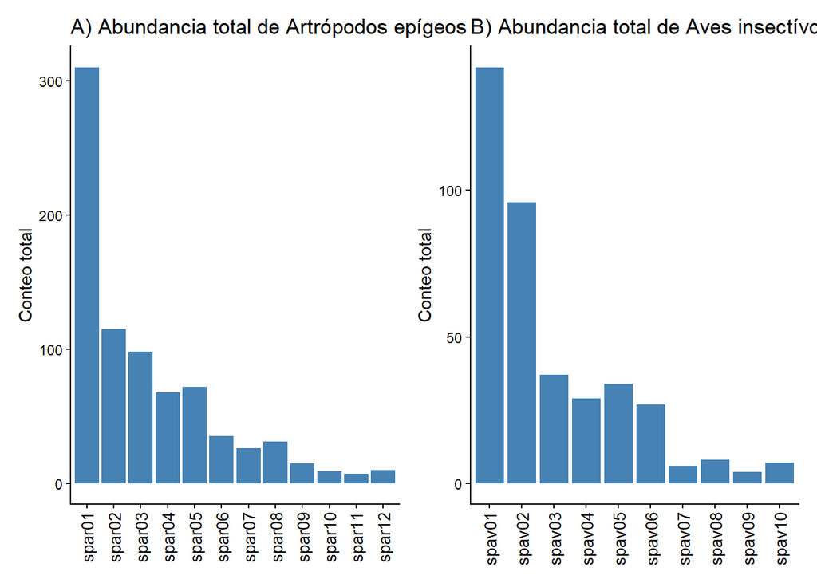

```r
# Transformamos los colSums directamente en Data Frames para ggplot
df_artr_tot <- data.frame(
  Especie    = names(colSums(artr_mat)),
  Abundancia = colSums(artr_mat)
)

df_aves_tot <- data.frame(
  Especie    = names(colSums(aves_mat)),
  Abundancia = colSums(aves_mat)
)

# Gráfico A: Ensamble de artrópodos epígeos
gg_artr_tot <- ggplot(df_artr_tot, aes(x = Especie, y = Abundancia)) +
  geom_col(fill = "steelblue") +
  labs(title = "A) Abundancia total de Artrópodos epígeos", x = NULL, y = "Conteo total") +
  theme_classic() +
  theme(axis.text.x = element_text(angle = 90, vjust = 0.5, hjust = 1, size = 10))

# Gráfico B: Ensamble de aves insectívoras
gg_aves_tot <- ggplot(df_aves_tot, aes(x = Especie, y = Abundancia)) +
  geom_col(fill = "steelblue") +
  labs(title = "B) Abundancia total de Aves insectívoras", x = NULL, y = "Conteo total") +
  theme_classic() +
  theme(axis.text.x = element_text(angle = 90, vjust = 0.5, hjust = 1, size = 10))

# Combinamos con patchwork
panel_abundancia_total <- gg_artr_tot + gg_aves_tot

# Guardamos con ggsave
ggsave(
  filename = "Panel_Abundancia_Total.png",
  plot     = panel_abundancia_total,
  width    = 9.5,
  height   = 5.0,
  dpi      = 300
)

panel_abundancia_total
```

Al las graficas de ambas comunidades se nota un patrón claro, las primeras especies (spav01 y spar01) son las mas dominantes,aunque en la comunidad de artrópodos esta dominancia se ve más clara que en aves.

```r
# Composición de comunidad de artrópodos con y sin desmaria
artr_long <- datos |>
  pivot_longer(cols = starts_with("spar"),
               names_to = "species",
               values_to = "abund") |>
  group_by(desmaria, species) |>
  summarise(abund = sum(abund), .groups = "drop")

stacked_artr <- ggplot(artr_long, aes(x = desmaria, y = abund, fill = species)) +
  geom_bar(stat = "identity", position = "fill") +
  labs(x = "Tratamiento",
       y = "Proporción de la abundancia total",
       title = "Composición de la comunidad de artrópodos") +
  theme_minimal()

# Composición de comunidad de aves con y sin desmaria
aves_long <- datos |>
  pivot_longer(cols = starts_with("spav"),
               names_to = "species",
               values_to = "abund") |>
  group_by(desmaria, species) |>
  summarise(abund = sum(abund), .groups = "drop")

stacked_aves <- ggplot(aves_long, aes(x = desmaria, y = abund, fill = species)) +
  geom_bar(stat = "identity", position = "fill") +
  labs(x = "Tratamiento",
       y = "Proporción de la abundancia total",
       title = "Composición de la comunidad de aves") +
  theme_minimal()

# Creamos un panel para los graficos y lo guardamos
panel_composicion <- (stacked_artr + stacked_aves) +
  plot_layout(guides = "collect") +
  plot_annotation(tag_levels = "A")
ggsave(
  filename = "Panel_Composicion_Comunidades.png",
  plot = panel_composicion,
  width = 11, height = 7, dpi = 300
)
```

Pero esto es meramente descriptivo, aún tenemos que poner a prueba estadísticamente nuestras observaciones. Una excelente herramienta estadística es el paquete mvabund, a diferencia de PERMANOVA, nos permite conservar la identidad de cada especie. Esto permite analizar la estructura detallada del ensamble como paso previo y riguroso antes de utilizar métricas globales como índices de diversidad por parcela. Dado que los datos son conteos de abundancia de organismos se sugiere que nuestra distribución debería ser de Poisson.

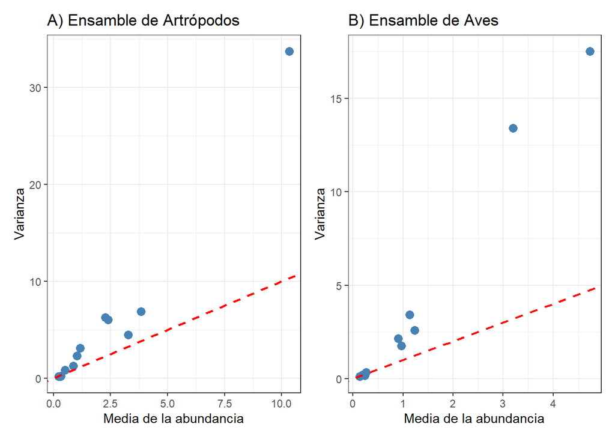

```r
# Para saber que distribución utilizar en nuestro análisis primero debemos revisar la relación varianza-media.

# Calculamos la varianza y media por grupo taxónomico
# Artrópodos
artr_means <- colMeans(artr_mat)
artr_vars  <- apply(artr_mat, 2, var)

# Aves
aves_means <- colMeans(aves_mat)
aves_vars  <- apply(aves_mat, 2, var)

# Generamos un data frame para ggplot
df_artr_mv <- data.frame(Media = artr_means, Varianza = artr_vars)
df_aves_mv <- data.frame(Media = aves_means, Varianza = aves_vars)

# Graficamos A: artrópodos
gg_artr_mv <- ggplot(df_artr_mv, aes(x = Media, y = Varianza)) +
  geom_point(col = "steelblue", size = 3) +
  geom_abline(intercept = 0, slope = 1, col = "red", linetype = "dashed", linewidth = 0.8) +
  labs(title = "A) Ensamble de Artrópodos", x = "Media de la abundancia", y = "Varianza") +
  theme_bw()

# Graficamos B: Aves
gg_aves_mv <- ggplot(df_aves_mv, aes(x = Media, y = Varianza)) +
  geom_point(col = "steelblue", size = 3) +
  geom_abline(intercept = 0, slope = 1, col = "red", linetype = "dashed", linewidth = 0.8) +
  labs(title = "B) Ensamble de Aves", x = "Media de la abundancia", y = "Varianza") +
  theme_bw()

# Combinamos ambos gráficos en un panel
panel_varianza_media <- gg_artr_mv + gg_aves_mv

# Guardamos el panel
ggsave(
  filename = "Panel_Varianza_Media.png",
  plot     = panel_varianza_media,
  width    = 9.5,
  height   = 4.8,
  dpi      = 300
)
panel_varianza_media
```

La línea segmentada roja representa el supuesto de Poisson, es decir, que la varianza es igual a la media, si observamos una mayor varianza que la media, entonces no podemos usar esta distribución. En ambos graficos observamos que los puntos azules que representan cada especie de artrópodo o de ave muestran sobredispersión, nuestro gráfico sugiere entonces utilizar una distribución Binomial negativa.

Para confirmar este diagnóstico gráfico de sobredispersión, ajustamos modelos con ambas distribuciones candidatas (Poisson y Binomial negaitva) y comparamos su ajuste mdiante QQ-plots de residuos generados por mvabund. Los puntos deben alinearse sobre la diagnoal, una curva en “S” o desviaciones enn los extremos indican un mal ajuste del modelo.

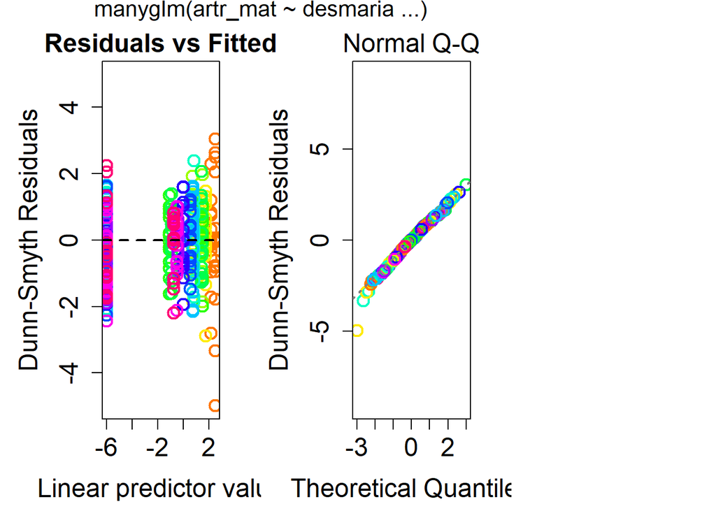

```r
# Probando distribuciones poisson y binomial negativa
modartr_poisson <- manyglm (artr_mat ~ desmaria, family = "poisson")
modartr_negbin <- manyglm(artr_mat ~ desmaria,
                          data = datos,
                          family = "negative.binomial")
op <- par (no.readonly = TRUE)
# Graficando los residuales
par(mfrow = c(1, 2))
plot(modartr_poisson, which = 1:2)
```

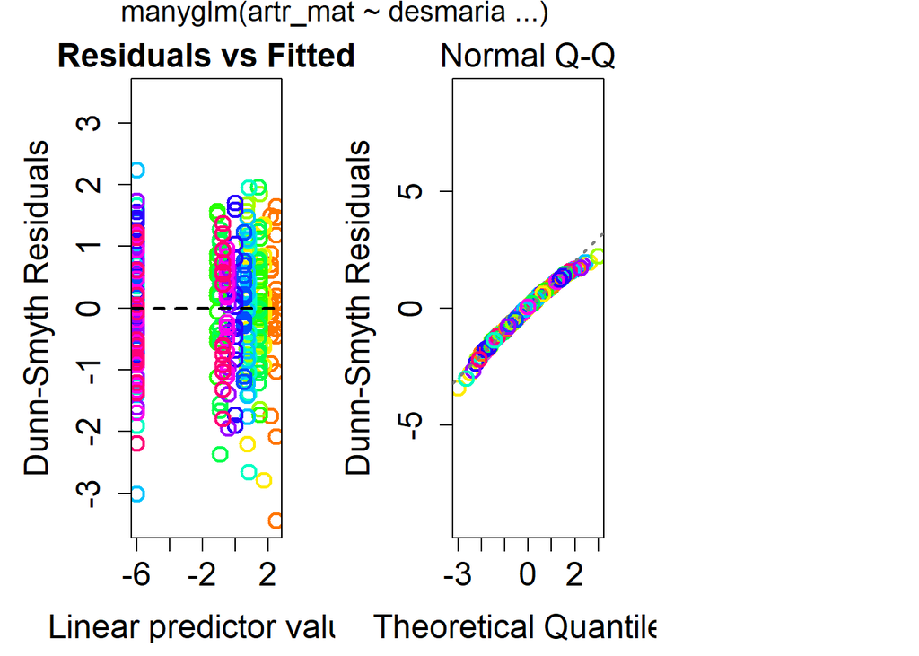

```r
plot(modartr_negbin, which = 1:2)
```

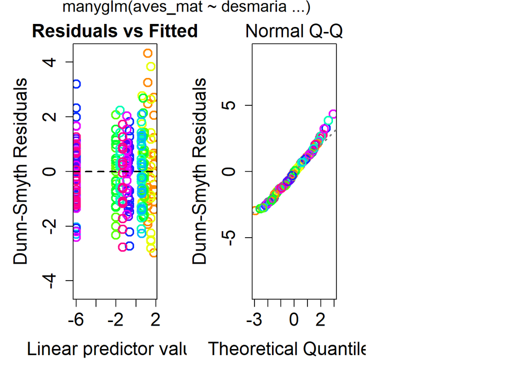

```r
# Probando distribuciones poisson y binomial negativa
modaves_poisson <- manyglm (aves_mat ~ desmaria, data= datos, family = "poisson")
modaves_negbin <- manyglm(aves_mat ~ desmaria,
                          data = datos,
                          family = "negative.binomial")
op <- par (no.readonly = TRUE)
# Graficando los residuales
par(mfrow = c(1, 2))
plot(modaves_poisson, which = 1:2)
```

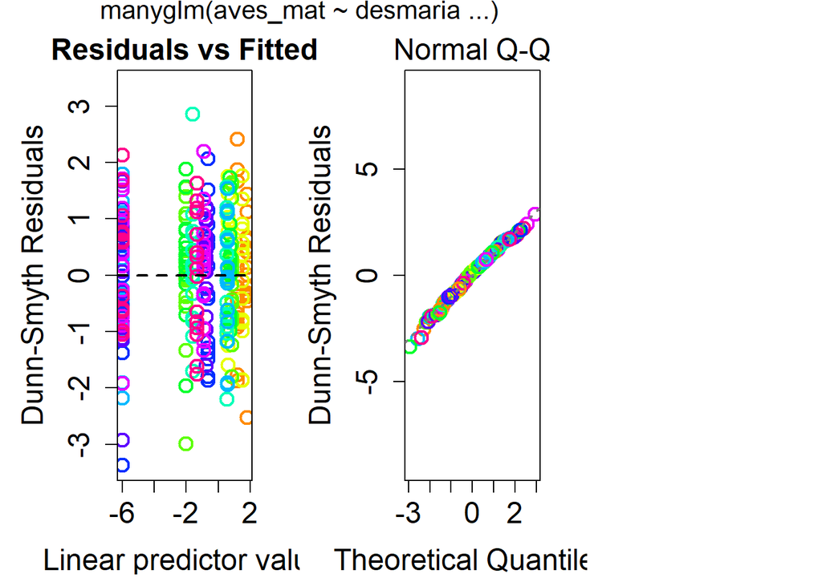

```r
plot(modaves_negbin, which = 1:2)
```

Una vez validada la distribución Binomial Negativa como una distribución adecuada para los datos, podemos evaluar si la composición de las comunidades de artrópodos y aves difieren significativamente en presencia y ausencia de *D. mutabilis* mediante pruebas de razón de verosimilitud con permutaciones.

```r
mv_aves <-anova(modaves_negbin, p.uni  = "adjusted",
                          nBoot  = 999,
                          test   = "LR")
```

```
## Time elapsed: 0 hr 0 min 3 sec
```

```r
print(mv_aves)
```

```
## Analysis of Deviance Table
##
## Model: aves_mat ~ desmaria
##
## Multivariate test:
##             Res.Df Df.diff   Dev Pr(>Dev)
## (Intercept)     29
## desmaria        28       1 118.9    0.001 ***
## ---
## Signif. codes:  0 '***' 0.001 '**' 0.01 '*' 0.05 '.' 0.1 ' ' 1
##
## Univariate Tests:
##             spav01          spav02          spav03          spav04
##                Dev Pr(>Dev)    Dev Pr(>Dev)    Dev Pr(>Dev)    Dev Pr(>Dev)
## (Intercept)
## desmaria     3.411    0.085  4.138    0.085  25.77    0.001 13.819    0.002
##             spav05          spav06          spav07          spav08
##                Dev Pr(>Dev)    Dev Pr(>Dev)    Dev Pr(>Dev)    Dev Pr(>Dev)
## (Intercept)
## desmaria     14.63    0.002 23.577    0.001  8.054    0.024 10.258    0.010
##             spav09          spav10
##                Dev Pr(>Dev)    Dev Pr(>Dev)
## (Intercept)
## desmaria     5.545    0.065  9.704    0.010
## Arguments:
##  Test statistics calculated assuming uncorrelated response (for faster computation)
## P-value calculated using 999 iterations via PIT-trap resampling.
```

```r
mv_artr <-anova(modartr_negbin, p.uni  = "adjusted",
                          nBoot  = 999,
                          test   = "LR")
```

```
## Time elapsed: 0 hr 0 min 4 sec
```

```r
print(mv_artr)
```

```
## Analysis of Deviance Table
##
## Model: artr_mat ~ desmaria
##
## Multivariate test:
##             Res.Df Df.diff   Dev Pr(>Dev)
## (Intercept)     29
## desmaria        28       1 255.3    0.001 ***
## ---
## Signif. codes:  0 '***' 0.001 '**' 0.01 '*' 0.05 '.' 0.1 ' ' 1
##
## Univariate Tests:
##             spar01          spar02          spar03          spar04
##                Dev Pr(>Dev)    Dev Pr(>Dev)    Dev Pr(>Dev)    Dev Pr(>Dev)
## (Intercept)
## desmaria     2.933    0.084 19.142    0.001 13.705    0.001 33.357    0.001
##             spar05          spar06          spar07          spar08
##                Dev Pr(>Dev)    Dev Pr(>Dev)    Dev Pr(>Dev)    Dev Pr(>Dev)
## (Intercept)
## desmaria    42.227    0.001 30.909    0.001 32.676    0.001 29.058    0.001
##             spar09          spar10          spar11          spar12
##                Dev Pr(>Dev)    Dev Pr(>Dev)    Dev Pr(>Dev)    Dev Pr(>Dev)
## (Intercept)
## desmaria    15.288    0.001 12.477    0.001  9.704    0.002 13.863    0.001
## Arguments:
##  Test statistics calculated assuming uncorrelated response (for faster computation)
## P-value calculated using 999 iterations via PIT-trap resampling.
```

Para visualizar los resultados del análisis multivariado, realizaremos un escalamiento multidimensional no métrico (NMDS), basado en distancias de Bray-Curtis, con el fin de ver las diferencias en las comunidades de artrópodos y aves entre ambos tratamientos.

```r
#Crear matriz de distancia Bray-Curtis y correr NMDS para artrópodos
artr.mds  <- metaMDS(artr_mat, distance = "bray")
```

```
## Wisconsin double standardization
## *** Best solution was not repeated -- monoMDS stopping criteria:
##     11: stress ratio > sratmax
##      9: scale factor of the gradient < sfgrmin
```

```r
# Ver el Stress del modelo
cat("Stress Artrópodos:", artr.mds$stress, "\n")
```

```
## Stress Artrópodos: 0.100643
```

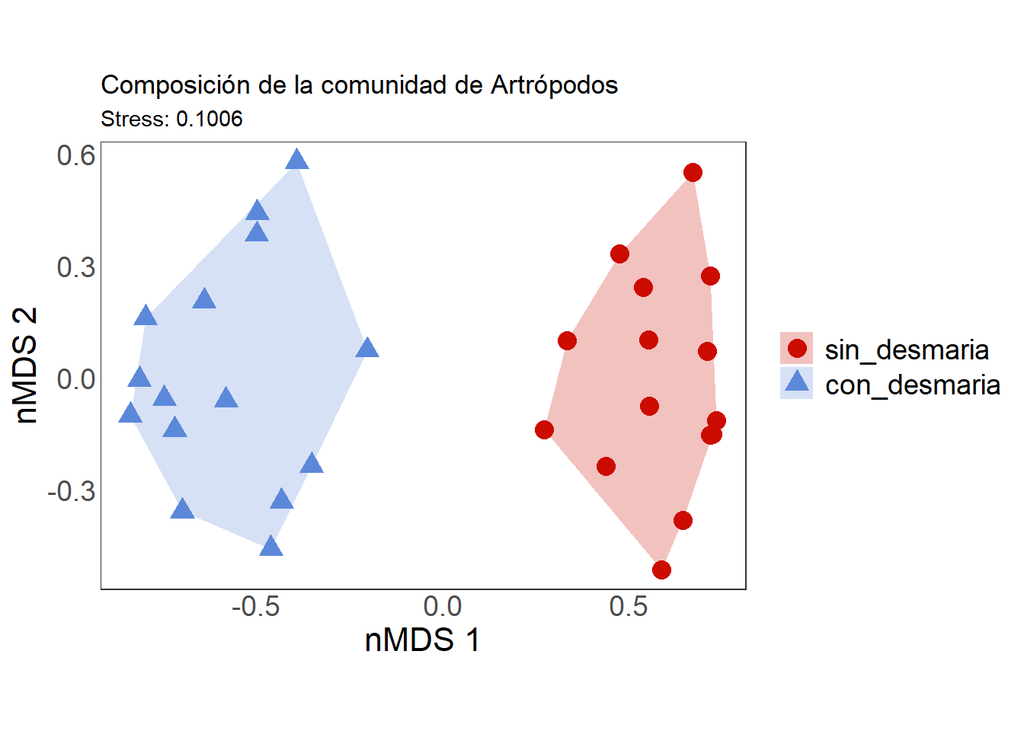

```r
# 2. Extraer los scores de las parcelas (sitios) y asociar el factor muérdago
artr.scores          <- as.data.frame(scores(artr.mds, display = "sites"))
artr.scores$plot     <- datos$plot
artr.scores$desmaria <- datos$desmaria

# 3. Calcular los polígonos (Hulls) por tratamiento
grp.sin.artr <- artr.scores[artr.scores$desmaria == "sin_desmaria", ][
  chull(artr.scores[artr.scores$desmaria == "sin_desmaria", c("NMDS1","NMDS2")]), ]

grp.con.artr <- artr.scores[artr.scores$desmaria == "con_desmaria", ][
  chull(artr.scores[artr.scores$desmaria == "con_desmaria", c("NMDS1","NMDS2")]), ]

hull.artr <- rbind(grp.sin.artr, grp.con.artr)

# 4. Graficar el NDMS con ggplot
artr.nmds.plot <- ggplot() +
  geom_polygon(data = hull.artr,
               aes(x = NMDS1, y = NMDS2, fill = desmaria, group = desmaria),
               alpha = 0.25) +
  geom_point(data = artr.scores,
             aes(x = NMDS1, y = NMDS2, shape = desmaria, colour = desmaria),
             size = 4) +
  coord_equal() +
  scale_fill_startrek() +
  scale_color_startrek() +
  theme_bw() +
  labs(x = "nMDS 1", y = "nMDS 2",
       title = "Composición de la comunidad de Artrópodos",
       subtitle = paste("Stress:", round(artr.mds$stress, 4))) +
  theme(axis.text.x  = element_text(size = 14),
        axis.text.y  = element_text(size = 14),
        axis.ticks   = element_blank(),
        axis.title.x = element_text(size = 16),
        axis.title.y = element_text(size = 16),
        panel.background = element_blank(),
        panel.grid.major = element_blank(),
        panel.grid.minor = element_blank(),
        plot.background  = element_blank(),
        legend.title = element_blank(),
        legend.text  = element_text(size = 14))

artr.nmds.plot
```

```r
# 1. Crear matriz de distancia Bray-Curtis y correr el NMDS para aves
aves.mds  <- metaMDS(aves_mat, distance = "bray", trymax = 100)
```

```
## Wisconsin double standardization
## *** Best solution repeated 1 times
```

```r
# Ver el Stress del modelo de aves
cat("Stress Aves:", aves.mds$stress, "\n")
```

```
## Stress Aves: 0.1338545
```

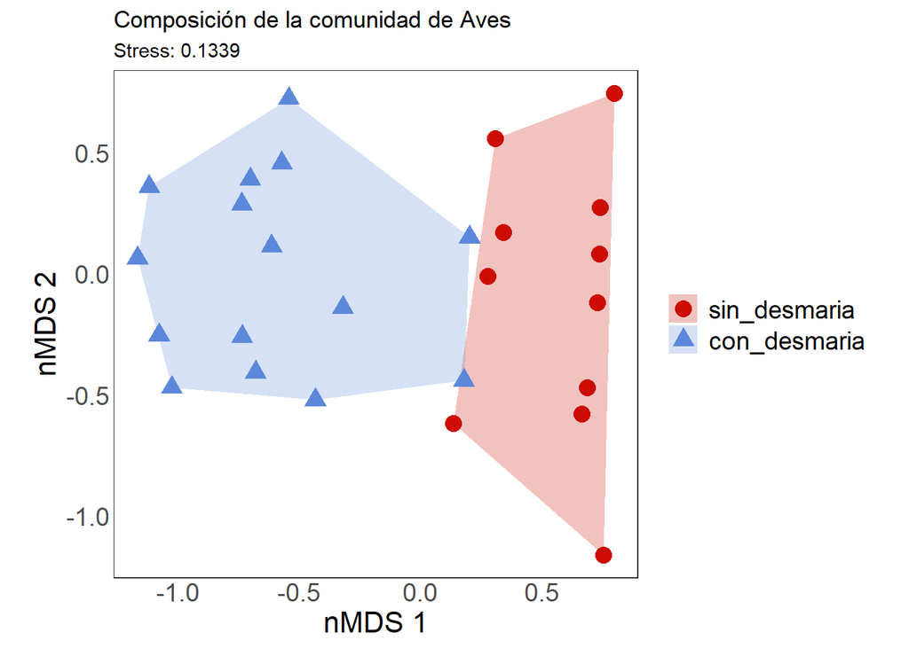

```r
# 2. Extraer los scores de las parcelas y asociar el factor muérdago
aves.pts <- aves.mds$points
aves.pts[,1] <- aves.pts[,1] - mean(aves.pts[,1])  # centrar NMDS1
aves.pts[,2] <- aves.pts[,2] - mean(aves.pts[,2])  # centrar NMDS2
aves.scores <- as.data.frame(aves.pts)
colnames(aves.scores) <- c("NMDS1", "NMDS2")
aves.scores$plot     <- datos$plot
aves.scores$desmaria <- datos$desmaria

# 3. Calcular los polígonos (Hulls) por tratamiento
grp.sin.aves <- aves.scores[aves.scores$desmaria == "sin_desmaria", ][
  chull(aves.scores[aves.scores$desmaria == "sin_desmaria", c("NMDS1","NMDS2")]), ]

grp.con.aves <- aves.scores[aves.scores$desmaria == "con_desmaria", ][
  chull(aves.scores[aves.scores$desmaria == "con_desmaria", c("NMDS1","NMDS2")]), ]

hull.aves <- rbind(grp.sin.aves, grp.con.aves)

# 4. Graficar el NMDS con ggplot
aves.nmds.plot <- ggplot() +
  geom_polygon(data = hull.aves,
               aes(x = NMDS1, y = NMDS2, fill = desmaria, group = desmaria),
               alpha = 0.25) +
  geom_point(data = aves.scores,
             aes(x = NMDS1, y = NMDS2, shape = desmaria, colour = desmaria),
             size = 4) +
  coord_equal() +
  scale_fill_startrek() +
  scale_color_startrek() +
  theme_bw() +
  labs(x = "nMDS 1", y = "nMDS 2",
       title = "Composición de la comunidad de Aves",
       subtitle = paste("Stress:", round(aves.mds$stress, 4))) +
  theme(axis.text.x  = element_text(size = 14),
        axis.text.y  = element_text(size = 14),
        axis.ticks   = element_blank(),
        axis.title.x = element_text(size = 16),
        axis.title.y = element_text(size = 16),
        panel.background = element_blank(),
        panel.grid.major = element_blank(),
        panel.grid.minor = element_blank(),
        plot.background  = element_blank(),
        legend.title = element_blank(),
        legend.text  = element_text(size = 14))
aves.nmds.plot
```

```r
# Creamos el panel para ambos NMDS y lo guardamos
panel_nmds <- (artr.nmds.plot + aves.nmds.plot) +
  plot_layout(guides = "collect") +
  plot_annotation(tag_levels = "A") &
  theme(legend.position = "right")

ggsave(
  filename = "Panel_NMDS_Final.png",
  plot = panel_nmds,
  width = 11, height = 7, dpi = 300
)
```

Obtuvimos valores de éstres de **0.1006** para el ensamble de artrópodos del suelo y de **0.1339** para la comunidad de aves insectívoras. Los valores de estrés situados en el rango de 0.10 a 0.20 representan ordenaciones aceptables e informativas, lo que demuestra un resultado confiable en las distancias de similitud real de nuestros datos biológicos.

Ahora sabemos que hay un cambio significativo en la estructura de las comunidades de aves y artrópodos, pero aún nos falta saber si estos cambios son por un cambio en la diversidad de estas comunidades. Por esta razón, evaluaremos tres métricas claves de diversidad alfa, como la riqueza (S), el índice de Shannon (H) y la equitatividad de Pielou (J).

```r
# Calculando riqueza, Shannon y equitatividad para las comunidades de artrópodos
datos$S_artr <- rowSums(artr_mat > 0)
datos$H_artr <- diversity(artr_mat, index = "shannon")
datos$J_artr <- datos$H_artr / log(datos$S_artr)
datos$J_artr[datos$S_artr == 1] <- 0

# Calculando riqueza, Shannon y equitatividad para las comunidades de aves
datos$S_aves <- rowSums(aves_mat > 0)
datos$H_aves <- diversity(aves_mat, index = "shannon")
datos$J_aves <- datos$H_aves / log(datos$S_aves)
datos$J_aves[datos$S_aves == 1] <- 0

# Generamos un objeto para agrupar los todos los índices de diversidad de las comunidades de artrópodos y aves
indices_long <- datos |>
  select(plot, desmaria, S_artr, H_artr, J_artr, S_aves, H_aves, J_aves) |>
  pivot_longer(
    cols      = c(S_artr, H_artr, J_artr, S_aves, H_aves, J_aves),
    names_to  = "indice",
    values_to = "valor"
  ) |>
  mutate(
    grupo  = if_else(str_detect(indice, "artr"), "Artrópodos", "Aves"),
    metrica = case_when(
      str_detect(indice, "^S") ~ "Riqueza (S)",
      str_detect(indice, "^H") ~ "Shannon (H')",
      str_detect(indice, "^J") ~ "Equitatividad (J)"
    )
  )
# --- 1. Calcular el resumen estadístico (Media y Desviación Estándar) ---
tabla_resumen <- indices_long |>
  group_by(grupo, metrica, desmaria) |>
  summarise(
    media = mean(valor, na.rm = TRUE),
    de    = sd(valor, na.rm = TRUE),
    .groups = "drop"
  ) |>
  # Formatear a texto con 3 decimales (Estándar científico: Media ± DE)
  mutate(valor_formateado = sprintf("%.3f ± %.3f", media, de)) |>
  # Seleccionar columnas clave y pivotar para dejar los tratamientos lado a lado
  select(grupo, metrica, desmaria, valor_formateado) |>
  pivot_wider(names_from = desmaria, values_from = valor_formateado) |>
  # Ordenar para que quede Artrópodos primero y luego Aves
  arrange(desc(grupo), metrica)

# --- 2. Generar la tabla con formato académico para el informe ---
knitr::kable(
  tabla_resumen,
  col.names = c("Grupo Taxonómico", "Índice de Diversidad", "Sin Desmaria (Control)", "Con Desmaria (Tratamiento)"),
  align = c("l", "l", "c", "c"),
  caption = "Tabla 1. Comparación de los índices de diversidad alfa (Media ± Desviación Estándar) en comunidades de artrópodos epígeos y aves insectívoras bajo el efecto del hemiparásito *Desmaria mutabilis*."
)
```

Tabla 1. Comparación de los índices de diversidad alfa (Media ± Desviación Estándar) en comunidades de artrópodos epígeos y aves insectívoras bajo el efecto del hemiparásito *Desmaria mutabilis*.

| Grupo Taxonómico | Índice de Diversidad | Sin Desmaria (Control) | Con Desmaria (Tratamiento) |
| --- | --- | --- | --- |
| Aves | Equitatividad (J) | 0.479 ± 0.417 | 0.864 ± 0.068 |
| Aves | Riqueza (S) | 1.933 ± 0.961 | 6.267 ± 1.387 |
| Aves | Shannon (H’) | 0.425 ± 0.388 | 1.557 ± 0.236 |
| Artrópodos | Equitatividad (J) | 0.729 ± 0.139 | 0.858 ± 0.056 |
| Artrópodos | Riqueza (S) | 3.600 ± 0.737 | 9.667 ± 1.345 |
| Artrópodos | Shannon (H’) | 0.927 ± 0.249 | 1.936 ± 0.168 |

En todas las métricas, Riqueza, Shannon y Equitatividad, para ambos grupos taxonómicos podemos observar un aumento en presencia de *D. mutabilis*. Pero esto es descriptivo, aún tenemos que poner a prueba si es que la presencia de *D. mutabilis* aumenta la diversidad en artrópodos y aves, para poner a prueba esta hipótesis haremos modelos lineales generalizados (GLMs).

El objetivo de este estudio es determinar si el aumento en la diversidad de artrópodos asociado a la presencia de *D. mutabilis* puede explicar un incremento en la diversidad de aves. Por tanto, realizaremos un GLM incluyendo el índice de diversidad de Shannon de aves como variable respuesta y como efectos fijos la pressencia de *D. mutabilis* y el índice de Shannon de artrópodos. Este análisis permitirá determinar si la diversidad de artrópodos explica variaciones en la diversidad de aves más allá del efecto directo asociado a la presencia del muérdago.

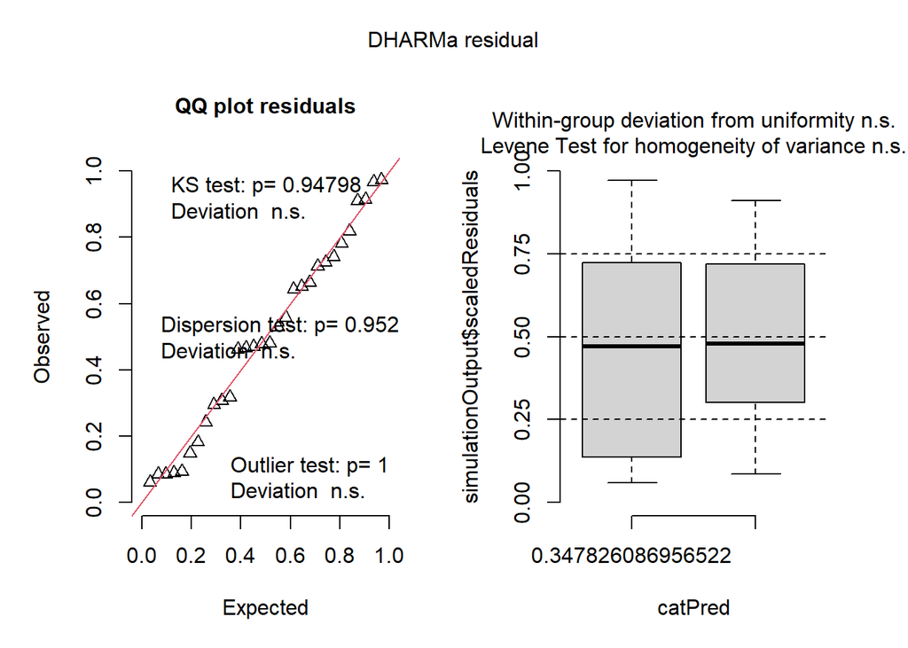

```r
# El índice de Shannon es nuestra variable respuesta en los GLMs, son datos continuos y positivos, al ser una métrica calculada y acumulativa, tiende a generar errores distribuidos de manera simétrica. Teniendo esto en cuenta y el principio de Parsimonia probaremos nuestros modelos con la distribución más simple que es la Gaussiana, la cual evaluaremos posteriormente con la uniformidad y dispersión de sus residuos simulados y con la prueba de normalidad de los residuos del modelo mediante Shapiro-Wilk.

glm_Hartr_gaus     <- glm(H_artr ~ desmaria,          data = datos, family = gaussian())
glm_Haves_gaus     <- glm(H_aves ~ desmaria,          data = datos, family = gaussian())

glm_mediacion_gaus <- glm(H_aves ~ H_artr + desmaria, data = datos, family = gaussian())

# Diagnósticos con DHARMa

sim_Hartr_gaus <- simulateResiduals(glm_Hartr_gaus, n = 1000)
plot(sim_Hartr_gaus, main = "DHARMa — H_artr | Gaussian")
```

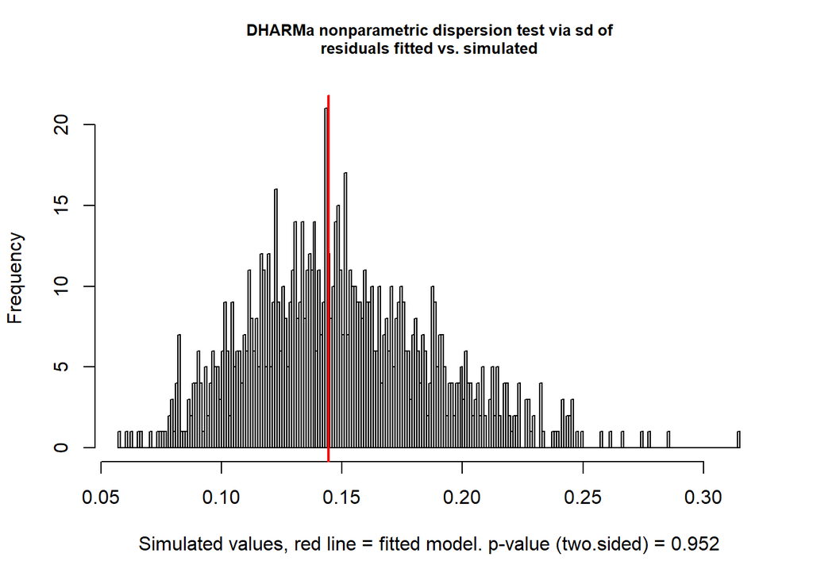

```
##
##  DHARMa nonparametric dispersion test via sd of residuals fitted vs.
##  simulated
##
## data:  simulationOutput
## dispersion = 0.96333, p-value = 0.952
## alternative hypothesis: two.sided
```

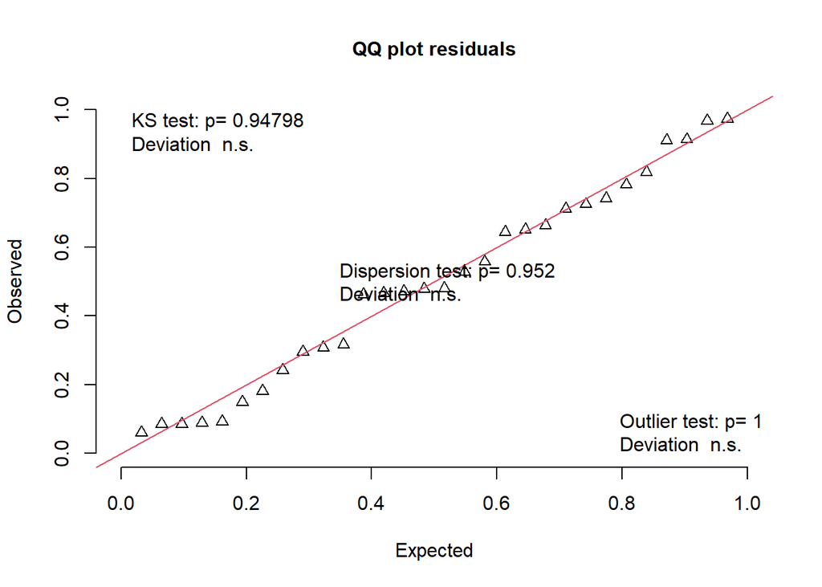

```
##
##  Asymptotic one-sample Kolmogorov-Smirnov test
##
## data:  simulationOutput$scaledResiduals
## D = 0.095333, p-value = 0.948
## alternative hypothesis: two-sided
```

```r
testDispersion(sim_Hartr_gaus); testUniformity(sim_Hartr_gaus)
```

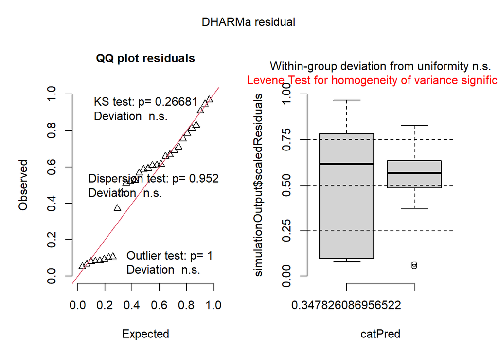

```r
sim_Haves_gaus <- simulateResiduals(glm_Haves_gaus, n = 1000)
plot(sim_Haves_gaus, main = "DHARMa — H_aves | Gaussian")
```

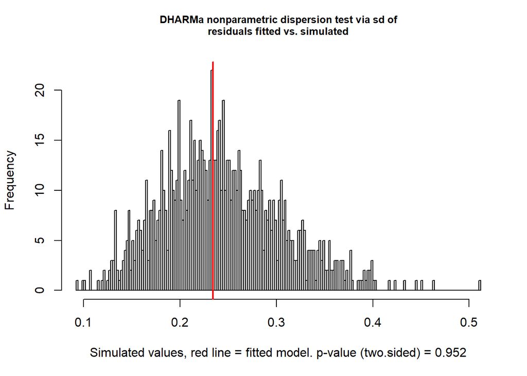

```
##
##  DHARMa nonparametric dispersion test via sd of residuals fitted vs.
##  simulated
##
## data:  simulationOutput
## dispersion = 0.96333, p-value = 0.952
## alternative hypothesis: two.sided
```

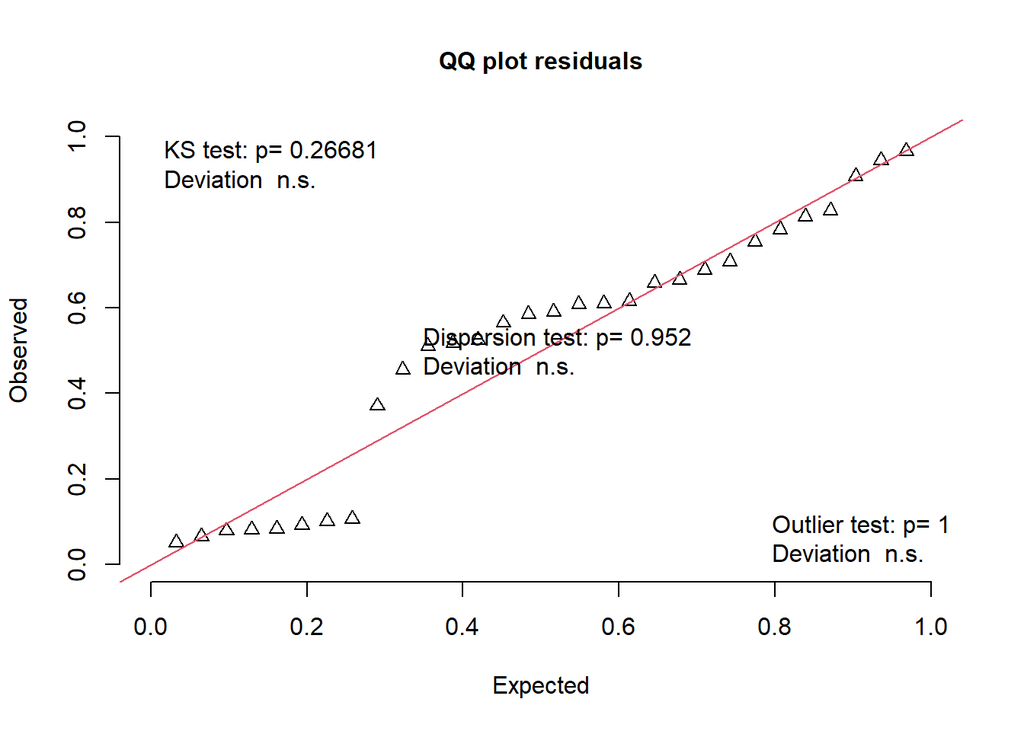

```
##
##  Exact one-sample Kolmogorov-Smirnov test
##
## data:  simulationOutput$scaledResiduals
## D = 0.17767, p-value = 0.2668
## alternative hypothesis: two-sided
```

```r
testDispersion(sim_Haves_gaus); testUniformity(sim_Haves_gaus)
```

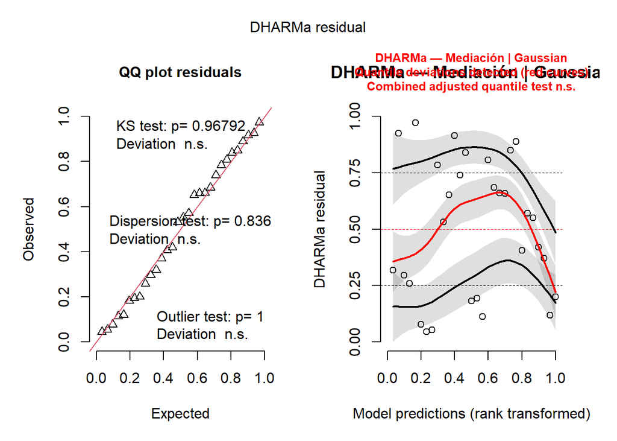

```r
sim_med_gaus <- simulateResiduals(glm_mediacion_gaus, n = 1000)
plot(sim_med_gaus, main = "DHARMa — Mediación | Gaussian")
```

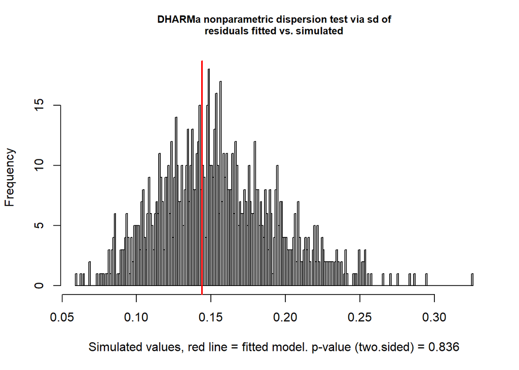

```
##
##  DHARMa nonparametric dispersion test via sd of residuals fitted vs.
##  simulated
##
## data:  simulationOutput
## dispersion = 0.92893, p-value = 0.836
## alternative hypothesis: two.sided
```

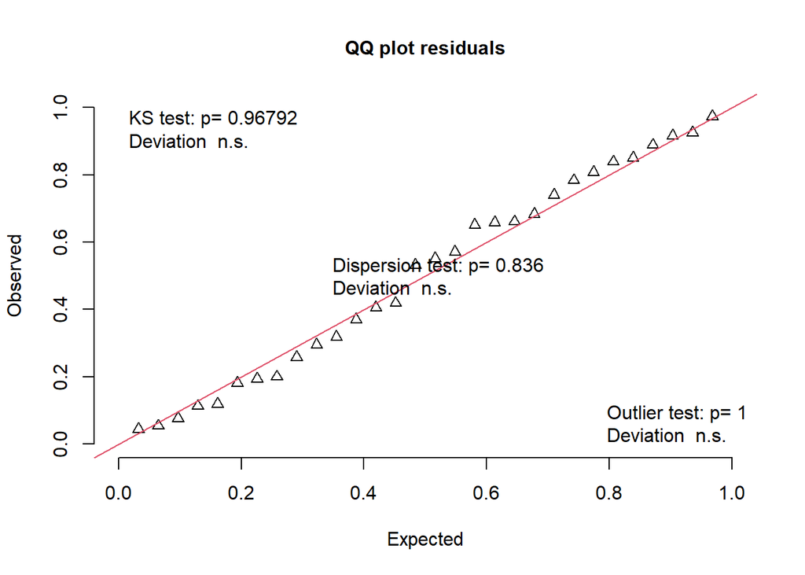

```
##
##  Exact one-sample Kolmogorov-Smirnov test
##
## data:  simulationOutput$scaledResiduals
## D = 0.085333, p-value = 0.9679
## alternative hypothesis: two-sided
```

```r
testDispersion(sim_med_gaus); testUniformity(sim_med_gaus)
```

```r
#  5. SHAPIRO-WILK
cat("\n── Shapiro-Wilk sobre residuos ──\n")
```

```
##
## ── Shapiro-Wilk sobre residuos ──
```

```r
cat("H_artr  | Gaussian : p =", round(shapiro.test(residuals(glm_Hartr_gaus))$p.value,     4), "\n")
```

```
## H_artr  | Gaussian : p = 0.416
```

```r
cat("H_aves  | Gaussian : p =", round(shapiro.test(residuals(glm_Haves_gaus))$p.value,     4), "\n")
```

```
## H_aves  | Gaussian : p = 0.0251
```

```r
cat("Mediac. | Gaussian : p =", round(shapiro.test(residuals(glm_mediacion_gaus))$p.value, 4), "\n")
```

```
## Mediac. | Gaussian : p = 0.538
```

```r
#Añadir diagnosticos

# GLMs
glm_H_artr <- glm(H_artr ~ desmaria, data = datos, family = gaussian)
glm_H_aves <- glm(H_aves ~ desmaria, data = datos, family = gaussian)


summary(glm_H_artr)
```

```
##
## Call:
## glm(formula = H_artr ~ desmaria, family = gaussian, data = datos)
##
## Coefficients:
##                      Estimate Std. Error t value Pr(>|t|)
## (Intercept)           0.92726    0.05483   16.91 3.14e-16 ***
## desmariacon_desmaria  1.00923    0.07755   13.02 2.14e-13 ***
## ---
## Signif. codes:  0 '***' 0.001 '**' 0.01 '*' 0.05 '.' 0.1 ' ' 1
##
## (Dispersion parameter for gaussian family taken to be 0.04510026)
##
##     Null deviance: 8.9019  on 29  degrees of freedom
## Residual deviance: 1.2628  on 28  degrees of freedom
## AIC: -3.8995
##
## Number of Fisher Scoring iterations: 2
```

```r
summary(glm_H_aves)
```

```
##
## Call:
## glm(formula = H_aves ~ desmaria, family = gaussian, data = datos)
##
## Coefficients:
##                      Estimate Std. Error t value Pr(>|t|)
## (Intercept)           0.42527    0.08303   5.122 1.99e-05 ***
## desmariacon_desmaria  1.13137    0.11742   9.635 2.17e-10 ***
## ---
## Signif. codes:  0 '***' 0.001 '**' 0.01 '*' 0.05 '.' 0.1 ' ' 1
##
## (Dispersion parameter for gaussian family taken to be 0.1034089)
##
##     Null deviance: 12.4955  on 29  degrees of freedom
## Residual deviance:  2.8954  on 28  degrees of freedom
## AIC: 20.995
##
## Number of Fisher Scoring iterations: 2
```

```r
# Mediación
glm_mediacion <- glm(H_aves ~ H_artr + desmaria, data = datos, family = gaussian)

summary(glm_mediacion)
```

```
##
## Call:
## glm(formula = H_aves ~ H_artr + desmaria, family = gaussian,
##     data = datos)
##
## Coefficients:
##                      Estimate Std. Error t value Pr(>|t|)
## (Intercept)           -0.4478     0.2217  -2.020 0.053461 .
## H_artr                 0.9416     0.2282   4.126 0.000317 ***
## desmariacon_desmaria   0.1811     0.2486   0.728 0.472640
## ---
## Signif. codes:  0 '***' 0.001 '**' 0.01 '*' 0.05 '.' 0.1 ' ' 1
##
## (Dispersion parameter for gaussian family taken to be 0.06577413)
##
##     Null deviance: 12.4955  on 29  degrees of freedom
## Residual deviance:  1.7759  on 27  degrees of freedom
## AIC: 8.3296
##
## Number of Fisher Scoring iterations: 2
```

El muérdago actúa facilitando indirectamente a las aves. No atrae a las aves de forma directa (como muestra la falta de significancia del factor muérdago en el modelo de mediación, P = 0.47), sino que altera la estructura de la comunidad de artrópodos epígeos al aumentar la diversidad, lo que en consecuencia genera un aumento en la diversidad de aves insectívoras.

El siguiente gráfico muestra la relación entre la diversidad de artrópodos epígeos y la diversidad de aves insectívoras por parcela en presencia o ausencia de *D. mutabilis*.

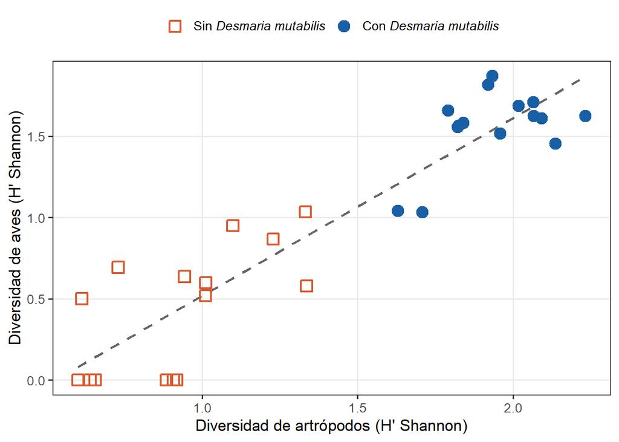

```r
mediacion_plot <-ggplot(datos, aes(H_artr, H_aves, colour = desmaria, shape = desmaria)) +
  # Añadimos aes(group = 1) aquí para unificar la recta:
  geom_smooth(aes(group = 1), method = "lm", se = FALSE, colour = "gray40",
              linetype = "dashed", linewidth = 0.9) +
  geom_point(size = 3.5, stroke = 1.2) +
  scale_colour_manual(values = c("sin_desmaria" = "#D85A30",
                                 "con_desmaria" = "#185FA5"),
                      labels = c("Sin *Desmaria mutabilis*", "Con *Desmaria mutabilis*")) +
  scale_shape_manual(values = c("sin_desmaria" = 0, "con_desmaria" = 19),
                     labels = c("Sin *Desmaria mutabilis*", "Con *Desmaria mutabilis*")) +
  labs(x = "Diversidad de artrópodos (H' Shannon)",
       y = "Diversidad de aves (H' Shannon)",
       colour = NULL, shape = NULL) +
  theme_bw(base_size = 13) +
  theme(legend.position = "top", panel.grid.minor = element_blank(),
legend.text = element_markdown()
  )
mediacion_plot
```

```r
ggsave(
  filename = "plot_de_mediacion.png",
  plot = mediacion_plot,
  width = 11, height = 7, dpi = 300
)
```

El gráfico muestra visualmente el mecanismo de la cascada, las parcelas con *D. mutabilis* (color azul) se ubican en la región de lata diversidad de artrópodos epígeos y alta diversidad de aves insectívoras, mientras que las parcelas sin *D. mutabilis* (color naranjo) se concentran en la región de baja diversidad de ambos ejes. Ambos grupos siguen la misma relación lineal, lo que sugiere que la diversidad de artrópodos es el que impulsa la diversidad de aves insectívoras.

Conclusiones

Los análisis realizados en este documento entregan evidencia consistente con la hipótesis planteada de una cascada de facilitación multitrófica mediada por *Desmaria mutabilis* en bosques de alta montaña de Nothofagus pumilio. La presencia de *D. mutabilis* modifica significativamente la composición y diversidad de las comunidades de artrópodos epígeos. Las especies especialistas, ausentes o muy escasas sin muérdago, fueron las principales impulsoras de este cambio.La presencia de *D. mutabilis* también modificó significativamente la composición y diversidad de las aves insectívoras. Al igual que en los artrópodos, la respuesta estuvo guiada por las especies especialistas, mientras que las generalistas no respondieron.

El análisis de mediación estadística determinó que el efecto de *D. mutabilis* sobre la diversidad de aves insectívoras está mediado por su efecto previo sobre la diversidad de artrópodos epígeos. Al incorporar la diversidad de artrópodos al modelo, el efecto directo del muérdago sobre las aves desapareció, mientras que el efecto del mediador se mantuvo significativo. Esto es consistente con mediación completa y con el mecanismo propuesto: el muérdago no atrae aves directamente.